# Homework 6

Samriddh gupta

# Libraries

```r
library(tidyverse)
library(ggplot2)
library(purrr)
library(modelr)
library(lubridate)
```

1. (2 pts) Create a dataset from hflights that has the Date, Day of the Week, and the number of flights for that date. Visualize the data both as a line graph (# of flights vs Date) and as a boxplot for each day of the week.

```r
data1<-hflights::hflights

data1 %>%
  mutate(Date=make_date(Year,Month,DayofMonth)) %>%
  select(Date,DayOfWeek) %>%
  group_by(Date) %>%
  mutate(NumberOfFlights=n())->
  data2

data2<-data2 %>%
  mutate(Wday=wday(Date,label = TRUE))

head(data2)
```

| Date | DayOfWeek | NumberOfFlights | Wday |
| --- | --- | --- | --- |
| 2011-01-01 | 6 | 552 | Sat |
| 2011-01-02 | 7 | 678 | Sun |
| 2011-01-03 | 1 | 702 | Mon |
| 2011-01-04 | 2 | 583 | Tue |
| 2011-01-05 | 3 | 590 | Wed |
| 2011-01-06 | 4 | 660 | Thu |

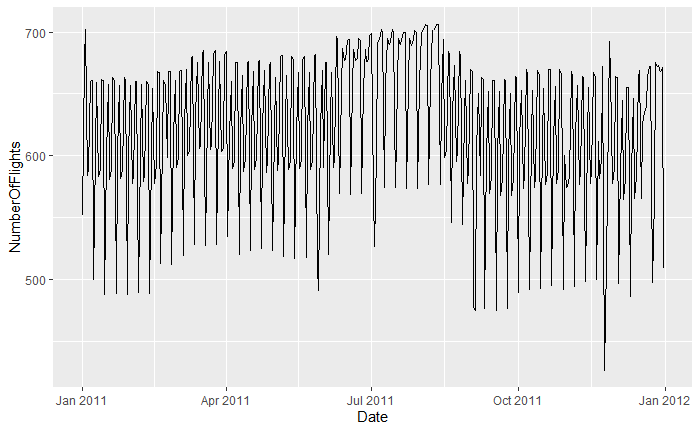

```r
ggplot(data = data2,mapping = aes(Date,NumberOfFlights))+
  geom_line()
```

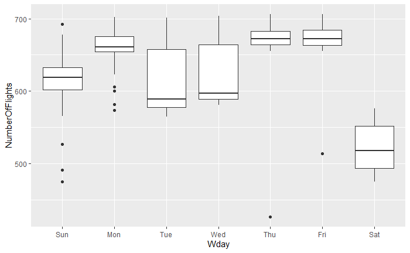

```r
g<-ggplot(data = data2,mapping = aes(Wday,NumberOfFlights))+
  geom_boxplot()

g
```

2. (1 pt) Construct a model using day of the week as the predictor. What does this model tell us? Visualize the residuals.

```r
mod <- lm(NumberOfFlights ~ Wday, data = data2)

grid <- data2 %>%
  data_grid(Wday) %>%
  add_predictions(mod, "NumberOfFlights")
grid
```

| Date | Wday | NumberOfFlights |
| --- | --- | --- |
| 2011-01-01 | Sun | 618.8751 |
| 2011-01-01 | Mon | 661.8264 |
| 2011-01-01 | Tue | 611.7317 |
| 2011-01-01 | Wed | 616.6011 |
| 2011-01-01 | Thu | 673.2134 |
| 2011-01-01 | Fri | 673.5548 |
| 2011-01-01 | Sat | 523.3296 |
| 2011-01-02 | Sun | 618.8751 |
| 2011-01-02 | Mon | 661.8264 |
| 2011-01-02 | Tue | 611.7317 |

[output cut: 990 more lines]

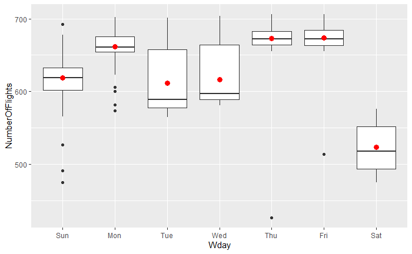

```r
## The model predicts the Number of the flights on any given week day.
g+geom_point(data = grid,color = "red", size = 3)
```

```r
data2 <- data2 %>%
  add_residuals(mod)
data2
```

| Date | DayOfWeek | NumberOfFlights | Wday | resid |
| --- | --- | --- | --- | --- |
| 2011-01-01 | 6 | 552 | Sat | 28.670419 |
| 2011-01-02 | 7 | 678 | Sun | 59.124899 |
| 2011-01-03 | 1 | 702 | Mon | 40.173632 |
| 2011-01-04 | 2 | 583 | Tue | -28.731650 |
| 2011-01-05 | 3 | 590 | Wed | -26.601140 |
| 2011-01-06 | 4 | 660 | Thu | -13.213398 |
| 2011-01-07 | 5 | 661 | Fri | -12.554787 |
| 2011-01-08 | 6 | 500 | Sat | -23.329581 |
| 2011-01-09 | 7 | 602 | Sun | -16.875101 |
| 2011-01-10 | 1 | 659 | Mon | -2.826368 |

[output cut: 990 more lines]

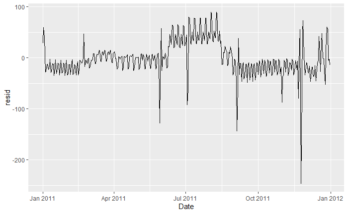

```r
ggplot(data = data2,mapping = aes(Date,resid))+
  geom_line()
```

(2 pts) Add a variable to account for seasonal variation. You can adjust the breaks something like this (feel free to change the dates)

season <- function(date) { cut(date, breaks = ymd(20110101, 20110301, 20110605, 201130905, 20120101), labels = c(“winter”,“spring”, “summer”, “fall”) ) }

mod1 <- lm(n ~ wday * season, data = daily) daily_res <- daily %>% add_residuals(mod1, “resid”)

```r
data2<-data2 %>%
  mutate(season=cut(Date,
                    breaks = ymd(20110101, 20110301, 20110605, 20110825, 20120101),
                    labels = c("winter","spring", "summer", "fall")))

mod1 <- lm(NumberOfFlights ~ Wday * season, data = data2)
daily_res <- data2 %>%
  add_residuals(mod1, "resid")

head(daily_res)
```

| Date | DayOfWeek | NumberOfFlights | Wday | resid | season |
| --- | --- | --- | --- | --- | --- |
| 2011-01-01 | 6 | 552 | Sat | 49.30064202 | winter |
| 2011-01-02 | 7 | 678 | Sun | 64.53310357 | winter |
| 2011-01-03 | 1 | 702 | Mon | 38.70705547 | winter |
| 2011-01-04 | 2 | 583 | Tue | -8.12669492 | winter |
| 2011-01-05 | 3 | 590 | Wed | -0.02838983 | winter |
| 2011-01-06 | 4 | 660 | Thu | -3.01470588 | winter |

```r
NA
```

4. (3 1/2 pts)
1. (1/2 pt) Identify the dates with the largest residual values. What do you think is the cause for the days with the highest and lowest residual values?

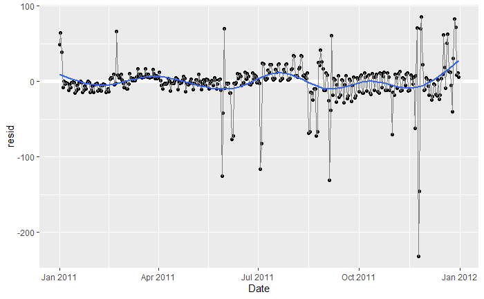

```r
daily_res %>%
  filter(abs(resid) > 100 ) %>%
  ggplot(data= daily_res,mapping=aes(Date, resid)) +
  geom_ref_line(h = 0) +
  geom_point(alpha = 1/3) +
  geom_line(color = "grey50") +
  geom_smooth(se = FALSE, span = 0.20)
```

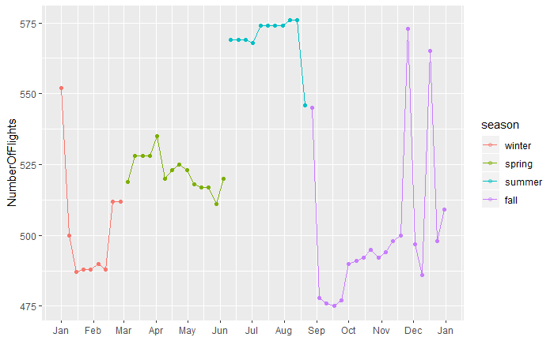

```r
daily_res %>%
  filter(Wday == "Sat") %>%
  ggplot(aes(Date, NumberOfFlights, colour = season)) +
  geom_point(alpha = 1/3) +
  geom_line() +
  scale_x_date(NULL, date_breaks = "1 month", date_labels = "%b")
```

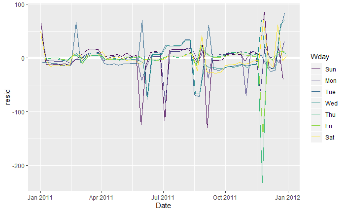

```r
daily_res %>%
  ggplot(aes(Date, resid, color = Wday)) +
  geom_ref_line(h = 0) +
  geom_line()
```

```r
## Most of the dates on the models appears to be holidays(If we look it at American Holiday calenders) and people like to travel at that time
```

2. (1 pt) Add a variable to identify dates fitting this criterion.

```r
data3<-data2 %>%
  mutate(Quarter=cut(Date,
                    breaks = ymd(20110101, 20110401, 20110701, 20111101, 20120101),
                    labels = c("Q1","Q2", "Q3", "Q4")))
tail(data3)
```

| Date | DayOfWeek | NumberOfFlights | Wday | resid | season | Quarter |
| --- | --- | --- | --- | --- | --- | --- |
| 2011-12-06 | 2 | 565 | Tue | -46.73165 | fall | Q4 |
| 2011-12-06 | 2 | 565 | Tue | -46.73165 | fall | Q4 |
| 2011-12-06 | 2 | 565 | Tue | -46.73165 | fall | Q4 |
| 2011-12-06 | 2 | 565 | Tue | -46.73165 | fall | Q4 |
| 2011-12-06 | 2 | 565 | Tue | -46.73165 | fall | Q4 |
| 2011-12-06 | 2 | 565 | Tue | -46.73165 | fall | Q4 |

3. (2 pts) Build a model to explain your data using the variables you now have. Visualize the residuals.

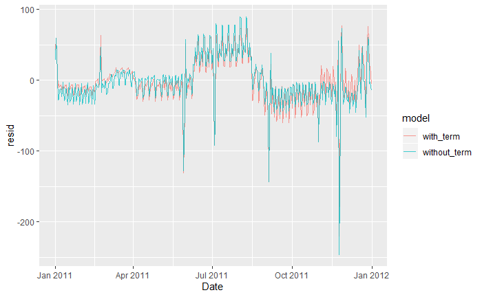

```r
mod1 <- lm(NumberOfFlights ~ Wday, data = data3)
mod2 <- lm(NumberOfFlights ~ Wday * Quarter, data = data3)

data3 %>%
  gather_residuals(without_term = mod1, with_term = mod2) %>%
  ggplot(aes(Date, resid, colour = model)) +
  geom_line(alpha = 0.75)
```

```r
data4<-data3%>%
  data_grid(Wday,Quarter,Date =seq(ymd(20200101),ymd(20201231),by=1) ) %>%
  add_predictions(mod2)
```

[output not shown]

```r
data4 %>%
  group_by(Date) %>%
  mutate(pred1=mean(pred))
```

| Wday | Quarter | Date | pred | pred1 |
| --- | --- | --- | --- | --- |
| Sun | Q1 | 2020-01-01 | 619.0562 | 623.7277 |
| Sun | Q1 | 2020-01-02 | 619.0562 | 623.7277 |
| Sun | Q1 | 2020-01-03 | 619.0562 | 623.7277 |
| Sun | Q1 | 2020-01-04 | 619.0562 | 623.7277 |
| Sun | Q1 | 2020-01-05 | 619.0562 | 623.7277 |
| Sun | Q1 | 2020-01-06 | 619.0562 | 623.7277 |
| Sun | Q1 | 2020-01-07 | 619.0562 | 623.7277 |
| Sun | Q1 | 2020-01-08 | 619.0562 | 623.7277 |
| Sun | Q1 | 2020-01-09 | 619.0562 | 623.7277 |
| Sun | Q1 | 2020-01-10 | 619.0562 | 623.7277 |

[output cut: 990 more lines]

```r
NA
```